# cm014 Worksheet: The Model-Fitting Paradigm in R

```r
suppressPackageStartupMessages(library(tidyverse))
library(gapminder)
library(broom)
```

So you want to fit a model to your data. How can you achieve this with R?

Topics:

1. What *is* model-fitting?
2. How do we fit a model in R?
3. How can we obtain tidy results from the model output?

## What is Model-Fitting?

When variables are not independent, then we can gain information about one variable if we know something about the other.

Examples: Use the scatterplot below:

1. A car weighs 4000 lbs. What can we say about its mpg?
2. A car weights less than 3000 lbs. What can we say about its mpg?

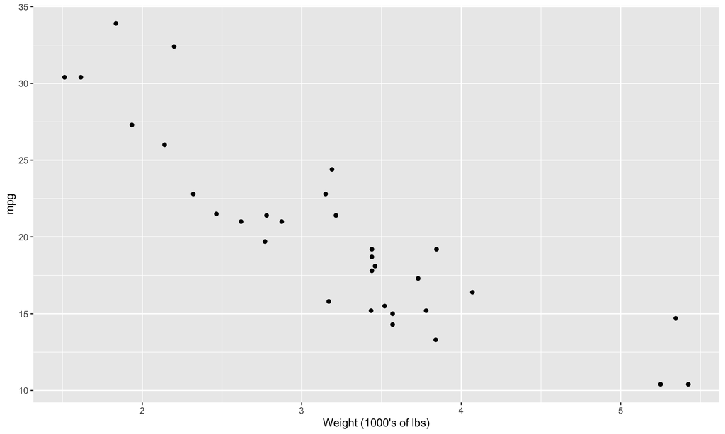

```r
library(tidyverse)
ggplot(mtcars, aes(wt, mpg)) +
  geom_point() +
  labs(x = "Weight (1000's of lbs)")
```

Example: What can we say about rear axle ratio if we know something about quarter mile time?

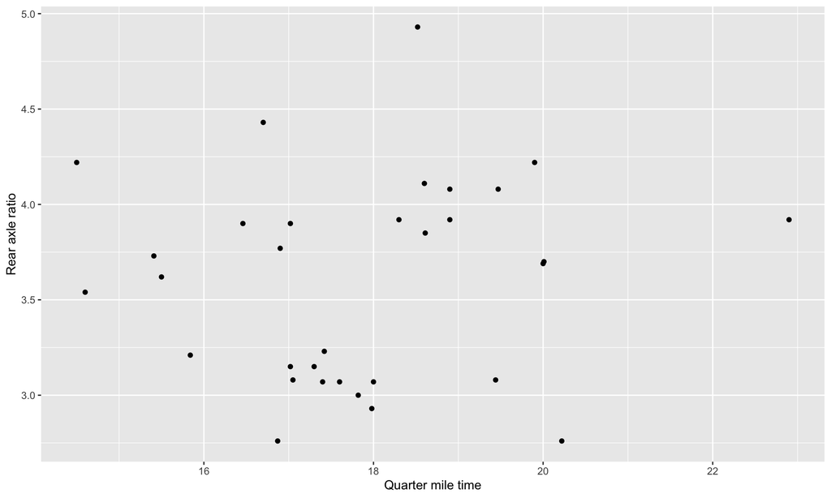

```r
ggplot(mtcars, aes(qsec, drat)) +
  geom_point() +
  labs(x = "Quarter mile time",
       y = "Rear axle ratio")
```

If EDA isn’t enough, we can answer these questions by fitting a model: a curve that predicts Y given X. Aka, a **regression curve** or a **machine learning model**.

(There are more comprehensive models too, such as modelling entire distributions, but that’s not what we’re doing here)

There are typically two goals of fitting a model:

1. Make predictions.
2. Interpret variable relationships.

## Fitting a model in R

Model fitting methods tend to use a common format in R:

```
method(formula, data, options)
```

They also tend to have a common output: a special *list*.

**Method**:

A function such as:

- Linear Regression: `lm`
- Generalized Linear Regression: `glm`
- Local regression: `loess`
- Quantile regression: `quantreg::rq`
- …

**Formula**:

In R, takes the form `y ~ x1 + x2 + ... + xp` (use column names in your data frame).

**Data**: The data frame.

**Options**: Specific to the method.

Exercise:

1. Fit a linear regression model to life expectancy (“Y”) from year (“X”) by filling in the formula. Notice what appears as the output.
2. On a new line, use the `unclass` function to uncover the object’s true nature: a list. Note: it might be easier to use the `names` function to see what components are included in the list.

| country | continent | year | lifeExp | pop | gdpPercap |
| --- | --- | --- | --- | --- | --- |
| France | Europe | 1952 | 67.410 | 42459667 | 7029.809 |
| France | Europe | 1957 | 68.930 | 44310863 | 8662.835 |
| France | Europe | 1962 | 70.510 | 47124000 | 10560.486 |
| France | Europe | 1967 | 71.550 | 49569000 | 12999.918 |
| France | Europe | 1972 | 72.380 | 51732000 | 16107.192 |
| France | Europe | 1977 | 73.830 | 53165019 | 18292.635 |
| France | Europe | 1982 | 74.890 | 54433565 | 20293.897 |
| France | Europe | 1987 | 76.340 | 55630100 | 22066.442 |
| France | Europe | 1992 | 77.460 | 57374179 | 24703.796 |
| France | Europe | 1997 | 78.640 | 58623428 | 25889.785 |

[output cut: 2 more lines]

Now, using the `lm()` function we will create the linear model

```r
(my_lm <- lm(lifeExp ~ year, data=gapminder_France))
```

```
Call:
lm(formula = lifeExp ~ year, data = gapminder_France)

Coefficients:
(Intercept)         year
  -397.7646       0.2385
```

Does that mean that the life expectency at “year 0” was equal to -397.7646?! We are interested in the modeling results around the modeling period which starts at year 1952. To get a meaniningful “interpretable” intercept we can use the `I()` function.

[figure not shown]

Use the `unclass()` function to take a look at how the `lm()` object actually looks like.

```r
unclass(my_lm)
```

[output not shown]

To complicate things further, some info is stored in *another* list after applying the `summary` function:

```r
summary(my_lm)
```

[output not shown]

We can use the `predict()` function to make predictions from the model (default is to use fitting/training data). Here are the predictions:

```r
predict(my_lm) %>%
  head()

plot(my_lm)
```

[output not shown]

Or we can predict on a new dataset:

```r
gapminder_France2 <- data.frame(year=seq(2000, 2005))
predict(my_lm, newdata=gapminder_France2) %>%
  head()
```

[output not shown]